# Tensorflow_Boosted_Trees_Classifier_with_Feature_Importance_Analysis

```python
import numpy as np
import pandas as pd

from itertools import cycle
from scipy import interp
import more_itertools as mit

# sklearn
from sklearn import metrics
from sklearn.model_selection import train_test_split
from sklearn.preprocessing import StandardScaler

# Tensorflow
import tensorflow as tf
tf.random.set_seed(123)

# Timer
from timeit import default_timer as timer

# Visualisation libraries

## IPython
from IPython.display import clear_output

## Text
from colorama import Fore, Back, Style
from IPython.display import Image, display, Markdown, Latex

## seaborn
import seaborn as sns
sns.set_context('paper', rc={'font.size':12,'axes.titlesize':14,'axes.labelsize':12})
sns.set_style('whitegrid')

## matplotlib
import matplotlib
import matplotlib.pyplot as plt
from matplotlib.patches import Ellipse, Polygon
import matplotlib.gridspec as gridspec
import matplotlib.colors
from pylab import rcParams
from matplotlib.font_manager import FontProperties
plt.rcParams['figure.figsize'] = 14, 8
plt.rcParams['axes.labelsize'] = 14
plt.rcParams['xtick.labelsize'] = 12
plt.rcParams['ytick.labelsize'] = 12
plt.rcParams['text.color'] = 'k'
%matplotlib inline

## plotly
from plotly.offline import init_notebook_mode, iplot
import plotly.graph_objs as go
import plotly.offline as py
from plotly.subplots import make_subplots
import plotly.express as px
%config InlineBackend.figure_format = 'retina'

import warnings
warnings.filterwarnings("ignore")
```

**Tensorflow Boosted Trees Classifier with Feature Importance Analysis**

In this article, we demonstrate solving a classification problem in TensorFlow using Estimators using the [Heart Disease Data Set](https://archive.ics.uci.edu/ml/datasets/Statlog+%28Heart%29) from the [UCI Machine Learning Repository](https://archive.ics.uci.edu/ml/datasets/Heart+Disease).

[figure not shown]

**Picture Source**: [harvard.edu](https://www.health.harvard.edu/heart-health/cardiovascular-disease-and-heart-disease-whats-the-difference)

### Attribute Information:

1. Age
2. Sex
   - 0: Female
   - 1: Male
3. Chest Pain Type
   - 1: Typical Angina
   - 2: Atypical Angina
   - 3: Non-Anginal Pain
   - 4: Asymptomatic
- Resting Blood Pressure
1. Serum Cholestoral (in mg/dl )
2. FBS: Fasting Blood Sugar > 120 mg/dl
   - 0 = False
   - 1 = True
3. Resting Electrocardiographic Results
   - 0: normal
   - 1: having ST-T wave abnormality (T wave inversions and/or ST elevation or depression of > 0.05 mV)
   - 2: showing probable or definite left ventricular hypertrophy by Estes' criteria
4. Maximum Heart Rate Achieved
5. Exercise Induced Angina
   - 0: No
   - 1: Yes
6. Oldpeak = St Depression Induced By Exercise Relative To Rest
7. Slope: The Slope Of The Peak Exercise ST Segment
   - 1: Upsloping
   - 2: Flat
   - 3: Downsloping
8. Number Of Major Vessels (0-3) Colored By Flourosopy
9. Thal
   - 3: Normal
   - 6: Fixed Defect
   - 7: Reversable Defect

### Variable to be predicted

- **Heart Disease**
  - 0: Absence
  - 1: Presence

```python
Data = np.genfromtxt('Data/heart.dat', delimiter=' ')
Attributes = ['Age', 'Sex', 'Chest Pain Type', 'Resting Blood Pressure', 'Serum Cholestoral',
              'Fasting Blood Sugar', 'Resting Electrocardiographic Results', 'Maximum Heart Rate Achieved',
              'Exercise Induced Angina', 'Oldpeak', 'Slope',
              'Number of Major Vessels', 'Thal', 'Heart Disease']
Data = pd.DataFrame(data = Data, columns = Attributes)
#
Temp = ['Sex', 'Chest Pain Type', 'Fasting Blood Sugar', 'Resting Electrocardiographic Results',
       'Exercise Induced Angina', 'Slope', 'Number of Major Vessels','Thal']
for c in Temp:
    Data[c] = Data[c].astype(int).astype(str)
del Temp, c
Target = 'Heart Disease'
Labels =   ['Absence', 'Presence']
Data['Heart Disease'] = (Data['Heart Disease']-1).astype(int)
#
display(Data.head(5))
display(pd.DataFrame({'Number of Instances': [Data.shape[0]], 'Number of Attributes': [Data.shape[1]]}).style.hide_index())


def Data_info(Inp, Only_NaN = False):
    Out = Inp.dtypes.to_frame(name='Data Type').sort_values(by=['Data Type'])
    Out = Out.join(Inp.isnull().sum().to_frame(name = 'Number of NaN Values'), how='outer')
    Out ['Size'] = Inp.shape[0]
    Out['Percentage'] = np.round(100*(Out['Number of NaN Values']/Inp.shape[0]),2)
    Out.index.name = 'Features'
    if Only_NaN:
        Out = Out.loc[Out['Number of NaN Values']>0]
    return Out

display(Data_info(Data))

# Maps
Maps = {'Sex': {'0':'Female', '1':'Male'},
        'Chest Pain Type': {'1':'Typical Angina', '2':'Atypical Angina', '3': 'Non-Anginal Pain', '4':'Asymptomatic'},
        'Fasting Blood Sugar': {'0': 'False', '1': 'True'}, 'Exercise Induced Angina': {'0': 'No', '1': 'Yes'},
        'Slope': {'1': 'Upsloping', '2': 'Flat', '3': 'Downsloping'},
        'Thal':  {'3': 'Normal', '6': 'Fixed Defect','7': 'Reversable Defect'}}
```

|  | Age | Sex | Chest Pain Type | Resting Blood Pressure | Serum Cholestoral | Fasting Blood Sugar | Resting Electrocardiographic Results | Maximum Heart Rate Achieved | Exercise Induced Angina | Oldpeak | Slope | Number of Major Vessels | Thal | Heart Disease |
| --- | --- | --- | --- | --- | --- | --- | --- | --- | --- | --- | --- | --- | --- | --- |
| 0 | 70.0 | 1 | 4 | 130.0 | 322.0 | 0 | 2 | 109.0 | 0 | 2.4 | 2 | 3 | 3 | 1 |
| 1 | 67.0 | 0 | 3 | 115.0 | 564.0 | 0 | 2 | 160.0 | 0 | 1.6 | 2 | 0 | 7 | 0 |
| 2 | 57.0 | 1 | 2 | 124.0 | 261.0 | 0 | 0 | 141.0 | 0 | 0.3 | 1 | 0 | 7 | 1 |
| 3 | 64.0 | 1 | 4 | 128.0 | 263.0 | 0 | 0 | 105.0 | 1 | 0.2 | 2 | 1 | 7 | 0 |
| 4 | 74.0 | 0 | 2 | 120.0 | 269.0 | 0 | 2 | 121.0 | 1 | 0.2 | 1 | 1 | 3 | 0 |

| Number of Instances | Number of Attributes |
| --- | --- |
| 270 | 14 |

| Features | Data Type | Number of NaN Values | Size | Percentage |
| --- | --- | --- | --- | --- |
| Age | float64 | 0 | 270 | 0.0 |
| Chest Pain Type | object | 0 | 270 | 0.0 |
| Exercise Induced Angina | object | 0 | 270 | 0.0 |
| Fasting Blood Sugar | object | 0 | 270 | 0.0 |
| Heart Disease | int32 | 0 | 270 | 0.0 |
| Maximum Heart Rate Achieved | float64 | 0 | 270 | 0.0 |
| Number of Major Vessels | object | 0 | 270 | 0.0 |
| Oldpeak | float64 | 0 | 270 | 0.0 |
| Resting Blood Pressure | float64 | 0 | 270 | 0.0 |
| Resting Electrocardiographic Results | object | 0 | 270 | 0.0 |
| Serum Cholestoral | float64 | 0 | 270 | 0.0 |
| Sex | object | 0 | 270 | 0.0 |
| Slope | object | 0 | 270 | 0.0 |
| Thal | object | 0 | 270 | 0.0 |

# Classification

## Train and Test sets

```python
# A copy of the Dataframe
df = Data.copy()
df.columns = [x.replace(' ','_') for x in df.columns]
Temp = Target.replace(' ','_')
X = df.drop(columns = Temp)
y = df[Temp].values
del df, Temp
Test_Size = 0.3

def Sets_Plot(Data, Test_Size):
    Temp = pd.DataFrame({'Set': ['Train', 'Test'],
             'Number of Instances':[int(Data.shape[0]*(1-Test_Size)), int(Data.shape[0]*Test_Size)]})
    Temp['Percentage'] = np.round(100* Temp['Number of Instances'].values /Temp['Number of Instances'].sum(), 2)
    fig = px.bar(Temp, y= ['',''], x= 'Number of Instances', orientation='h', color = 'Set', text = 'Percentage',
                 color_discrete_sequence = ['PaleGreen', 'LightBlue'], height = 180)
    fig.update_layout(plot_bgcolor= 'white', legend_orientation='h', legend=dict(x=0, y=1.7),
                      xaxis = dict(tickmode = 'array', tickvals = [0, Data.shape[0]], ticktext = ['','']))
    fig.update_traces(marker_line_color= 'Black', marker_line_width=1.5, opacity=1)
    fig.update_traces(texttemplate='%{text:.2}%      ', textposition='inside')
    fig.update_xaxes(title_text=None, range=[0, Data.shape[0]])
    fig.update_yaxes(title_text=None)
    fig.show()
X_train, X_test, y_train, y_test = train_test_split(X, y, test_size= Test_Size, random_state=42)
display(pd.DataFrame(data={'Set':['X_train','X_test','y_train','y_test'],
                           'Shape':[X_train.shape, X_test.shape, y_train.shape, y_test.shape]}).set_index('Set').T)
Sets_Plot(Data, Test_Size)
```

| Set | X_train | X_test | y_train | y_test |
| --- | --- | --- | --- | --- |
| Shape | (189, 13) | (81, 13) | (189,) | (81,) |

[interactive chart not shown]

## Feature Columns

Create the feature columns, using the original numeric columns as is and one-hot-encoding categorical variables.

```python
def Feat_Columns(Inp, Numeric = False, disp_dtype = False):
    '''
    Feature Columns function
    Input: Dataset
    Output: Tensorflow Feature Column List
    '''
    if not Numeric:
        Numeric = ['int64', 'int32', 'float64', 'float32']
    Temp = Inp.dtypes.reset_index(drop = False)
    Temp.columns = ['Features', 'Data Type']
    Temp['Data Type'] = Temp['Data Type'].astype(str)
    # Numeric_Columns
    Numeric_Columns = Temp.loc[Temp['Data Type'].isin(Numeric), 'Features'].tolist()
    # Categorical_Columns
#     Categorical_Columns = Temp.loc[(~Temp['Data Type'].isin(Numeric)), 'Features'].tolist()
    Categorical_Columns = Temp.loc[Temp['Data Type'] == 'object','Features'].tolist()
    if disp_dtype:
        display(pd.DataFrame({'Numeric Columns': [', '.join(Numeric_Columns)],
                  'Categorical Columns': [', '.join(Categorical_Columns)]}, index = ['Columns']).T.style)
    # Feature Columns
    feature_columns = []
    if len(Categorical_Columns)>0:
        for feature_name in Categorical_Columns:
            vocabulary = Inp[feature_name].unique()
            feature_columns.append(tf.feature_column.indicator_column(\
                                      tf.feature_column.categorical_column_with_vocabulary_list(feature_name, vocabulary)))
    if len(Numeric_Columns)>0:
        for feature_name in Numeric_Columns:
            feature_columns.append(tf.feature_column.numeric_column(feature_name))
    return feature_columns
```

## Input Function

The **input function** specifies how data is converted to a tf.data.Dataset that feeds the input pipeline in a streaming fashion. Moreover, an **input function** is a function that returns a `tf.data.Dataset` object which outputs the following two-element tuple:

- [`features`](https://developers.google.com/machine-learning/glossary/#feature) - A Python dictionary in which:
  - Each key is the name of a feature.
  - Each value is an array containing all of that feature's values.
- `label` - An array containing the values of the label for every example.

```python
def make_input_fn(X, y, inmemory_train = False, n_epochs= None, shuffle=True, batch_size = 256):
    # Not In memory Training
    if not inmemory_train:
        def input_fn():
            dataset = tf.data.Dataset.from_tensor_slices((X.to_dict(orient='list'), y))
            if shuffle:
                dataset = dataset.shuffle(1000)
            dataset = (dataset.repeat(n_epochs).batch(batch_size))
            return dataset
    # In memory Training
    if inmemory_train:
        y = np.expand_dims(y, axis=1)
        def input_fn():
            return dict(X), y
    # End
    return input_fn
```

## Building the input pipeline

```python
my_feature_columns = Feat_Columns(X)
# Training and evaluation input functions.
train_input_fn = make_input_fn(X_train, y_train)
eval_input_fn = make_input_fn(X_test, y_test, shuffle=False, n_epochs=1)
```

## Training the model

```python
# Classifier
tf.keras.backend.clear_session()
IT = int(1e3)
params = {'n_trees': 50, 'max_depth': 3, 'n_batches_per_layer': 1, 'center_bias': True}
classifier =  tf.estimator.BoostedTreesClassifier(my_feature_columns, **params)
# Train model.
start = timer()
classifier.train(train_input_fn, max_steps = IT)
CPU_Time = timer() - start
# Evaluation.
results = classifier.evaluate(eval_input_fn)
clear_output()
results['CPU Time'] = CPU_Time
display(pd.DataFrame(results, index = ['']).round(4))
```

|  | accuracy | accuracy_baseline | auc | auc_precision_recall | average_loss | label/mean | loss | precision | prediction/mean | recall | global_step | CPU Time |
| --- | --- | --- | --- | --- | --- | --- | --- | --- | --- | --- | --- | --- |
|  | 0.7654 | 0.6049 | 0.8801 | 0.8459 | 0.4552 | 0.3951 | 0.4552 | 0.7826 | 0.3223 | 0.5625 | 188 | 6.0902 |

An alternative way to train a model with boosting performance is using the **train_in_memory** feature. However, if there is no issue with performance or long training time is not a concern, training without this feature is recommended [2]. Furthermore, our observations have shown that using train_in_memory not always increases the performance of the training.

```python
in_memory_params = dict(params)
in_memory_params['n_batches_per_layer'] = 1
# In-memory input_fn does not use batching.
train_input_fn = make_input_fn(X_train, y_train, inmemory_train = True)

# Classifier
tf.keras.backend.clear_session()
classifier =  tf.estimator.BoostedTreesClassifier(my_feature_columns, train_in_memory=True, **in_memory_params)
# Train model.
start = timer()
classifier.train(train_input_fn, max_steps = IT)
CPU_Time = timer() - start
# Evaluation.
results = classifier.evaluate(eval_input_fn)
clear_output()
results['CPU Time'] = CPU_Time
display(pd.DataFrame(results, index = ['']).round(4))
```

|  | accuracy | accuracy_baseline | auc | auc_precision_recall | average_loss | label/mean | loss | precision | prediction/mean | recall | global_step | CPU Time |
| --- | --- | --- | --- | --- | --- | --- | --- | --- | --- | --- | --- | --- |
|  | 0.7778 | 0.6049 | 0.8779 | 0.8379 | 0.4502 | 0.3951 | 0.4502 | 0.7692 | 0.3398 | 0.625 | 152 | 8.2573 |

# Feature Importance

We can investigate the feature importance of an artificial classification task. This is similar to that of [scikit-learn](https://scikit-learn.org/stable/auto_examples/ensemble/plot_forest_importances.html) and has been outlined in [6].

```python
pred_dicts = list(classifier.experimental_predict_with_explanations(eval_input_fn))
clear_output()

# Create DFC Pandas dataframe.
labels = y_test
probs = pd.Series([pred['probabilities'][1] for pred in pred_dicts])
df_dfc = pd.DataFrame([pred['dfc'] for pred in pred_dicts])
display(df_dfc.describe().T.style.background_gradient(subset= ['mean'], cmap='RdYlGn')\
        .background_gradient(subset= ['std'], cmap='RdYlGn')\
        .background_gradient(subset= ['min'], cmap='hot')\
        .background_gradient(subset= ['max'], cmap='winter').set_precision(4))
```

|  | count | mean | std | min | 25% | 50% | 75% | max |
| --- | --- | --- | --- | --- | --- | --- | --- | --- |
| Number_of_Major_Vessels | 81.0000 | 0.0075 | 0.0882 | -0.1439 | -0.0531 | -0.0272 | 0.0559 | 0.2178 |
| Oldpeak | 81.0000 | -0.0348 | 0.1101 | -0.1624 | -0.0961 | -0.0807 | -0.0072 | 0.4197 |
| Chest_Pain_Type | 81.0000 | -0.0091 | 0.0833 | -0.1366 | -0.0779 | -0.0483 | 0.0765 | 0.1483 |
| Maximum_Heart_Rate_Achieved | 81.0000 | -0.0121 | 0.0510 | -0.2139 | -0.0276 | -0.0101 | 0.0095 | 0.1150 |
| Serum_Cholestoral | 81.0000 | -0.0186 | 0.0542 | -0.1421 | -0.0441 | -0.0244 | 0.0029 | 0.1492 |
| Slope | 81.0000 | -0.0000 | 0.0406 | -0.1118 | -0.0319 | -0.0175 | 0.0304 | 0.0811 |
| Thal | 81.0000 | -0.0293 | 0.0945 | -0.2528 | -0.0976 | -0.0639 | 0.0541 | 0.3065 |
| Resting_Blood_Pressure | 81.0000 | 0.0107 | 0.0745 | -0.2189 | -0.0246 | -0.0062 | 0.0284 | 0.3317 |
| Resting_Electrocardiographic_Results | 81.0000 | 0.0054 | 0.0167 | -0.0277 | -0.0027 | 0.0000 | 0.0095 | 0.0639 |
| Sex | 81.0000 | -0.0050 | 0.0480 | -0.1398 | -0.0444 | 0.0067 | 0.0220 | 0.1114 |
| Exercise_Induced_Angina | 81.0000 | -0.0198 | 0.0423 | -0.1072 | -0.0467 | -0.0333 | -0.0108 | 0.1118 |
| Age | 81.0000 | -0.0208 | 0.0547 | -0.1478 | -0.0552 | -0.0297 | 0.0019 | 0.1605 |
| Fasting_Blood_Sugar | 81.0000 | 0.0000 | 0.0000 | 0.0000 | 0.0000 | 0.0000 | 0.0000 | 0.0000 |

A nice property of DFCs is that the sum of the contributions + the bias is equal to the prediction for a given example.

```python
# Sum of DFCs + bias == probabality.
bias = pred_dicts[0]['bias']
dfc_prob = df_dfc.sum(axis=1) + bias
np.testing.assert_almost_equal(dfc_prob.values, probs.values)
```

## Feature Importance for a patient

Plot DFCs for an individual patient which is color-coded based on the contributions' directionality and add the feature values on the figure.

```python
def _add_feature_values(feature_values, ax, colors):
    """Display feature's values on left of plot."""
    x_coord = ax.get_xlim()[0]
    OFFSET = 0.15
    for y_coord, (feat_name, feat_val) in enumerate(feature_values.items()):
        t = plt.text(x_coord, y_coord - OFFSET, '{}'.format(feat_val), size=12)
        t.set_bbox(dict(facecolor= colors[y_coord], alpha=0.25))
    font = FontProperties()
#     font.set_weight('bold')
    t = plt.text(x_coord, y_coord + 1 - OFFSET, 'Feature\nValue',
    fontproperties=font, size=14)

def _yaxis_labels(ax):
    y_labels = []
    for c in [c.get_text() for c in ax.get_yticklabels()]:
        List = list(mit.locate(c, lambda x: x == " "))
        if len(List)>1:
            List = List[1::2]
            Temp1 = list(c)
            for position in List:
                Temp1[position] = '\n'
            c = "".join(Temp1)
        y_labels.append(c)
    return y_labels

def _xLims(ax):
    Temp = np.linspace(-1,1,21, endpoint=True)
    Temp = np.round(Temp,1)
    xlims = ax.get_xlim()
    for l, r in list(zip(Temp[:-1],Temp[1:])):
        if l<= xlims[0] < r:
            Left = l
        if l<= xlims[1] < r:
            Right = r
    return [Left, Right]

def Plot_Example(example, TOP_N = 10, Pos_Color = 'LimeGreen', Neg_Color = 'OrangeRed', Maps = Maps, FS = (13, 7)):
    example.index = [x.replace('_',' ') for x in example.index]
    # Sorting by absolute value
    sorted_ix = example.abs().sort_values()[-TOP_N:].index
    example = example[sorted_ix]
    colors = example.map(lambda x: Pos_Color if x >= 0 else Neg_Color).tolist()
    fig, ax = plt.subplots(1, 1, figsize= FS)
    _ = example.to_frame().plot(kind='barh', color=[colors], edgecolor = 'white', hatch = '///',
                                 legend=None, alpha=0.75, ax = ax)
    _ = example.to_frame().plot(kind='barh', color='None', edgecolor = 'Black',
                                legend=None, alpha=1, lw=1., ax = ax)
    ax.grid(False, axis='y')
    # Y axis Labels

    ax.set_yticklabels(_yaxis_labels(ax), size=12)
    # x axis Limits
    _ = ax.set_xlim(_xLims(ax))

    # Add feature values.
    Temp = X_test.copy()
    Temp.columns = [x.replace('_',' ') for x in Temp.columns]
    for c in Maps.keys():
        Temp[c] = Temp[c].map(Maps[c])

    _add_feature_values(Temp.iloc[ID][sorted_ix], ax, colors)
    return ax
```

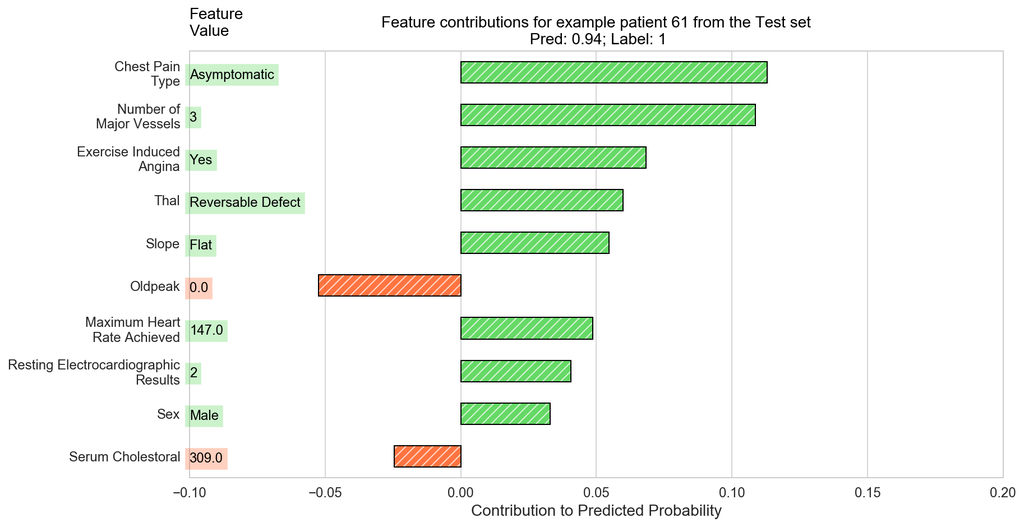

```python
# Plot results.
# ID = np.random.choice(len(y_test), 1)[0]
ID = 61
ax = Plot_Example(df_dfc.iloc[ID])
_ = ax.set_title('Feature contributions for example patient {} from the Test set\n Pred: {:1.2f}; Label: {}'
                 .format(ID, probs[ID], labels[ID]))
_ = ax.set_xlabel('Contribution to Predicted Probability', size=14)
```

## Global feature importances

### Gain-based feature importances

Gain-based feature importances are built into the TensorFlow Boosted Trees estimators using `classifier.experimental_feature_importances`.

```python
importances = classifier.experimental_feature_importances(normalize=True)
df_imp = pd.Series(importances)
TOP_N = 10
Temp = df_imp.iloc[0:TOP_N][::-1].reset_index()
Temp.columns = ['Features','Importance']
Temp['Features'] = Temp['Features'].map(lambda x: x.replace('_',' '))
```

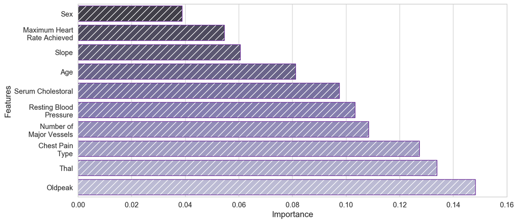

```python
importances = classifier.experimental_feature_importances(normalize=True)

def Plot_FeatImportance(pds, TOP_N = 10, FS = (13, 6)):
    Temp = pds.iloc[0:TOP_N][::-1].reset_index()
    Temp.columns = ['Features','Importance']
    Temp = Temp.sort_values(by=['Importance'])
    Temp['Features'] = Temp['Features'].map(lambda x: x.replace('_',' '))

    fig, ax = plt.subplots(1, 1, figsize = FS)
    _ = sns.barplot(ax = ax, x='Importance', y= 'Features', data= Temp, palette="Purples_d", hatch = '//')
    _ = sns.barplot(ax = ax, x='Importance', y= 'Features', data= Temp, facecolor = 'None', edgecolor = 'Indigo')
    _ = ax.grid(False, axis='y')
    # Y axis Labels
    _ = ax.set_yticklabels(_yaxis_labels(ax), size=12)
    # x axis Limits
    _ = ax.set_xlim(_xLims(ax))
    return ax

ax = Plot_FeatImportance(pd.Series(importances))
_ = ax.set_xlim(right = .16)
```

### Average absolute DFCs

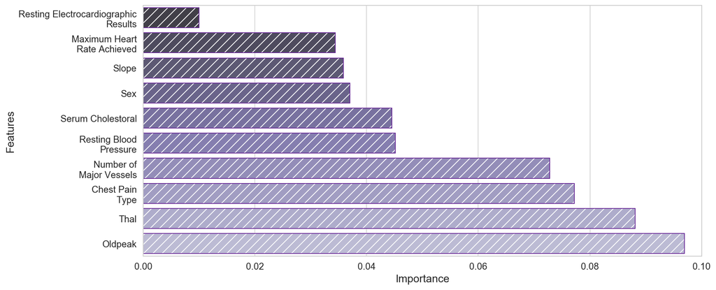

```python
ax = Plot_FeatImportance(df_dfc.abs().mean())
_ = ax.set_xlim(right = .1)
```

### Permutation feature importance

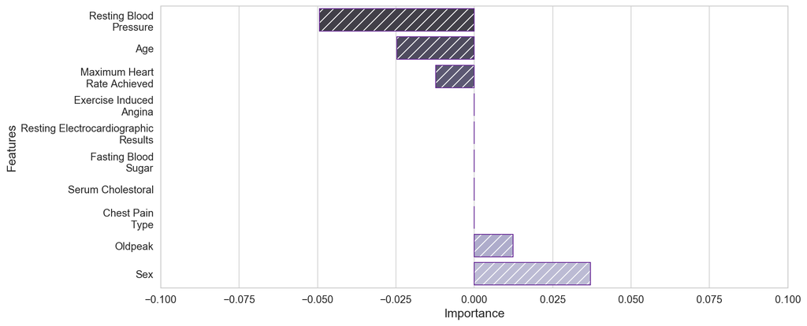

```python
def permutation_importances(est, X_eval, y_test, metric, features):
    """Column by column, shuffle values and observe effect on eval set.

    source: http://explained.ai/rf-importance/index.html
    A similar approach can be done during training. See "Drop-column importance"
    in the above article."""
    baseline = metric(est, X_eval, y_test)
    imp = []
    for col in features:
        save = X_eval[col].copy()
        X_eval[col] = np.random.permutation(X_eval[col])
        m = metric(est, X_eval, y_test)
        X_eval[col] = save
        imp.append(baseline - m)
    return np.array(imp)

def accuracy_metric(est, X, y):
    """TensorFlow estimator accuracy."""
    eval_input_fn = make_input_fn(X,
                                  y=y,
                                  shuffle=False,
                                  n_epochs=1)
    return est.evaluate(input_fn=eval_input_fn)['accuracy']
features = X_train.columns.tolist()
importances = permutation_importances(classifier, X_test, y_test, accuracy_metric,
                                      features)
df_imp = pd.Series(importances, index=features)
clear_output()

_ = Plot_FeatImportance(df_imp)
```

# References

1. Regression analysis. Wikipedia. Last edited on 17 April 2020, at 13:31 (UTC). https://en.wikipedia.org/wiki/Regression_analysis
2. Tensorflow tutorials, https://www.tensorflow.org/tutorials
3. TensorFlow Boosted Trees Classifier, https://www.tensorflow.org/api_docs/python/tf/estimator/BoostedTreesClassifier?version=nightly
4. Lasso (statistics), https://en.wikipedia.org/wiki/Lasso_(statistics).
5. Tikhonov regularizationm https://en.wikipedia.org/wiki/Tikhonov_regularization.
6. Palczewska A., Palczewski J., Marchese Robinson R., Neagu D. (2014) [Interpreting Random Forest Classification Models Using a Feature Contribution Method](https://link.springer.com/chapter/10.1007/978-3-319-04717-1_9). In: Bouabana-Tebibel T., Rubin S. (eds) Integration of Reusable Systems. Advances in Intelligent Systems and Computing, vol 263. Springer, Cham
7. James, G., Witten, D., Hastie, T., & Tibshirani, R. (2013). [An introduction to statistical learning](https://link.springer.com/book/10.1007/978-1-4614-7138-7) (Vol. 112, pp. 3-7). New York: springer.
8. Jordi Warmenhoven, ISLR-python
9. James, G., Witten, D., Hastie, T., & Tibshirani, R. (2017). [ISLR: Data for an Introduction to Statistical Learning with Applications in R](https://cran.r-project.org/web/packages/ISLR/index.html)